# Project report

Machine Learning (CSC8111) 2020/21\ Titanic - Machine Learning from Disaster\ HONG, HU

# 1. Project diagram

[figure not shown]

# 2. Libraries

The following are some libraries that will be used in the project:

```python
# data analysis and wrangling
import pandas as pd
import numpy as np
import random as rnd

# visualization
import seaborn as sns
import matplotlib.pyplot as plt

# machine learning
from sklearn.linear_model import LogisticRegression
from sklearn.svm import SVC, LinearSVC
from sklearn.ensemble import RandomForestClassifier
from sklearn.neighbors import KNeighborsClassifier
from sklearn.naive_bayes import GaussianNB
from sklearn.linear_model import Perceptron
from sklearn.linear_model import SGDClassifier
from sklearn.tree import DecisionTreeClassifier
```

# 3. Gain data

We can use Pandas to help us process data. First, you can read the training data and test data into Pandas DataFrames. We will also combine these two data sets to perform specific operations on the two data sets at the same time.

```python
# set pandas
pd.set_option('display.width', 1000)

# use pandas to manage data
train_data = pd.read_csv('data/train.csv')
test_data = pd.read_csv('data/test.csv')
combine = [train_data, test_data]
```

# 4. Analyze data

Pandas can also help us describe data sets. We can view the data set through the following question and answer:

What features are available in the data set?

The first thing to note is that the description of the features in the data set has been given in the problem description. The description of the features in the data set is as follows:\

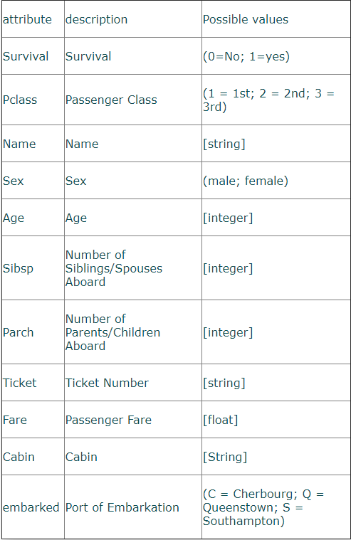

As we can know from these data, let us view the fields in the training set:

```python
print(train_data.columns.values)
```

```
['PassengerId' 'Survived' 'Pclass' 'Name' 'Sex' 'Age' 'SibSp' 'Parch'
 'Ticket' 'Fare' 'Cabin' 'Embarked']
```

### Which features are discrete?

These discrete values can classify the sample into a series of similar samples. In discrete features, are their values based on nouns? Or is it based on order? Or is it ratio-based? Or is it based on the interval class? In addition, this can help us choose the right graph for the data to visualize.

In this question, the discrete variables are: Survived, Sex and Embarked. Based on the sequence: Pclass.

### Which features are numerical?

The value of these data varies from sample to sample. In numerical features, are their values discrete or continuous? Or is it based on time series? In addition, this can help us choose the right graph for the data to visualize.

In this problem, the continuous numerical features are: Age, Fare. Discrete values are: SibSp, Parch.

```python
train_data.head()
```

|  | PassengerId | Survived | Pclass | Name | Sex | Age | SibSp | Parch | Ticket | Fare | Cabin | Embarked |
| --- | --- | --- | --- | --- | --- | --- | --- | --- | --- | --- | --- | --- |
| 0 | 1 | 0 | 3 | Braund, Mr. Owen Harris | male | 22.0 | 1 | 0 | A/5 21171 | 7.2500 | NaN | S |
| 1 | 2 | 1 | 1 | Cumings, Mrs. John Bradley (Florence Briggs Th... | female | 38.0 | 1 | 0 | PC 17599 | 71.2833 | C85 | C |
| 2 | 3 | 1 | 3 | Heikkinen, Miss. Laina | female | 26.0 | 0 | 0 | STON/O2. 3101282 | 7.9250 | NaN | S |
| 3 | 4 | 1 | 1 | Futrelle, Mrs. Jacques Heath (Lily May Peel) | female | 35.0 | 1 | 0 | 113803 | 53.1000 | C123 | S |
| 4 | 5 | 0 | 3 | Allen, Mr. William Henry | male | 35.0 | 0 | 0 | 373450 | 8.0500 | NaN | S |

### Which characteristics are mixed data?

Numerical and alphanumeric data are under the same feature. These may be the target data we need to modify.

In this question, Ticket is a data type that mixes numeric and alphanumeric data, and Cabin is alphanumeric data.

### Which features may contain incorrect data?

It may be difficult to find these in a large data set, but by observing a small number of samples in a small data set, it may also be possible to fully tell us which features need to be corrected.

In this question, the characteristics of Name may contain errors or typos, because there are several ways to describe the name.

```python
train_data.tail()
```

|  | PassengerId | Survived | Pclass | Name | Sex | Age | SibSp | Parch | Ticket | Fare | Cabin | Embarked |
| --- | --- | --- | --- | --- | --- | --- | --- | --- | --- | --- | --- | --- |
| 886 | 887 | 0 | 2 | Montvila, Rev. Juozas | male | 27.0 | 0 | 0 | 211536 | 13.00 | NaN | S |
| 887 | 888 | 1 | 1 | Graham, Miss. Margaret Edith | female | 19.0 | 0 | 0 | 112053 | 30.00 | B42 | S |
| 888 | 889 | 0 | 3 | Johnston, Miss. Catherine Helen "Carrie" | female | NaN | 1 | 2 | W./C. 6607 | 23.45 | NaN | S |
| 889 | 890 | 1 | 1 | Behr, Mr. Karl Howell | male | 26.0 | 0 | 0 | 111369 | 30.00 | C148 | C |
| 890 | 891 | 0 | 3 | Dooley, Mr. Patrick | male | 32.0 | 0 | 0 | 370376 | 7.75 | NaN | Q |

### Which features contain spaces, null or empty values?

These spaces, null values or empty values are likely to need correction.

In this question:

1. The number of these features containing null values is: Cabin> Age> Embarked.
2. The size of the number of incomplete data in the training set is: Cabin> Age.

### What is the data type under each feature?

This can be of great help when we do data conversion.

In this question:

1. Seven features are int type or float type. There are 6 in the test data set.
2. There are 5 characteristics of string (object) type.

```python
train_data.info()
```

```
<class 'pandas.core.frame.DataFrame'>
RangeIndex: 891 entries, 0 to 890
Data columns (total 12 columns):
 #   Column       Non-Null Count  Dtype
---  ------       --------------  -----
 0   PassengerId  891 non-null    int64
 1   Survived     891 non-null    int64
 2   Pclass       891 non-null    int64
 3   Name         891 non-null    object
 4   Sex          891 non-null    object
 5   Age          714 non-null    float64
 6   SibSp        891 non-null    int64
 7   Parch        891 non-null    int64
 8   Ticket       891 non-null    object
 9   Fare         891 non-null    float64
 10  Cabin        204 non-null    object
 11  Embarked     889 non-null    object
dtypes: float64(2), int64(5), object(5)
memory usage: 83.7+ KB
```

```python
test_data.info()
```

```
<class 'pandas.core.frame.DataFrame'>
RangeIndex: 418 entries, 0 to 417
Data columns (total 11 columns):
 #   Column       Non-Null Count  Dtype
---  ------       --------------  -----
 0   PassengerId  418 non-null    int64
 1   Pclass       418 non-null    int64
 2   Name         418 non-null    object
 3   Sex          418 non-null    object
 4   Age          332 non-null    float64
 5   SibSp        418 non-null    int64
 6   Parch        418 non-null    int64
 7   Ticket       418 non-null    object
 8   Fare         417 non-null    float64
 9   Cabin        91 non-null     object
 10  Embarked     418 non-null    object
dtypes: float64(2), int64(4), object(5)
memory usage: 36.0+ KB
```

### What is the numerical distribution of numerical features in the sample?

This can help us initially understand “how the training data set reflects actual problems.”

In this question:

1. A total of 891 samples.
2. Survived label is distinguished by 0 or 1.
3. About 38% of the samples are survived.
4. Most passengers (>76%) did not travel with parents or children.
5. About 30% of passengers have relatives and/or spouses boarding together.
6. The fare difference is very big, a small number of passengers (<1%) paid up to $512.
7. Very few passengers (<1% ) are between 64-80.

We can obtain the above information in the following ways:

```python
train_data.describe()
```

|  | PassengerId | Survived | Pclass | Age | SibSp | Parch | Fare |
| --- | --- | --- | --- | --- | --- | --- | --- |
| count | 891.000000 | 891.000000 | 891.000000 | 714.000000 | 891.000000 | 891.000000 | 891.000000 |
| mean | 446.000000 | 0.383838 | 2.308642 | 29.699118 | 0.523008 | 0.381594 | 32.204208 |
| std | 257.353842 | 0.486592 | 0.836071 | 14.526497 | 1.102743 | 0.806057 | 49.693429 |
| min | 1.000000 | 0.000000 | 1.000000 | 0.420000 | 0.000000 | 0.000000 | 0.000000 |
| 25% | 223.500000 | 0.000000 | 2.000000 | 20.125000 | 0.000000 | 0.000000 | 7.910400 |
| 50% | 446.000000 | 0.000000 | 3.000000 | 28.000000 | 0.000000 | 0.000000 | 14.454200 |
| 75% | 668.500000 | 1.000000 | 3.000000 | 38.000000 | 1.000000 | 0.000000 | 31.000000 |
| max | 891.000000 | 1.000000 | 3.000000 | 80.000000 | 8.000000 | 6.000000 | 512.329200 |

```python
#By using percentiles=[.61, .62] to view the data set, we can see that the survival rate is 38%
train_data.describe(percentiles=[.61, .62])
```

|  | PassengerId | Survived | Pclass | Age | SibSp | Parch | Fare |
| --- | --- | --- | --- | --- | --- | --- | --- |
| count | 891.000000 | 891.000000 | 891.000000 | 714.000000 | 891.000000 | 891.000000 | 891.000000 |
| mean | 446.000000 | 0.383838 | 2.308642 | 29.699118 | 0.523008 | 0.381594 | 32.204208 |
| std | 257.353842 | 0.486592 | 0.836071 | 14.526497 | 1.102743 | 0.806057 | 49.693429 |
| min | 1.000000 | 0.000000 | 1.000000 | 0.420000 | 0.000000 | 0.000000 | 0.000000 |
| 50% | 446.000000 | 0.000000 | 3.000000 | 28.000000 | 0.000000 | 0.000000 | 14.454200 |
| 61% | 543.900000 | 0.000000 | 3.000000 | 32.000000 | 0.000000 | 0.000000 | 23.225000 |
| 62% | 552.800000 | 1.000000 | 3.000000 | 32.000000 | 0.000000 | 0.000000 | 24.150000 |
| max | 891.000000 | 1.000000 | 3.000000 | 80.000000 | 8.000000 | 6.000000 | 512.329200 |

```python
#View the distribution of Parch by using percentiles=[.76, .77]
train_data.describe(percentiles=[.76, .77])
```

|  | PassengerId | Survived | Pclass | Age | SibSp | Parch | Fare |
| --- | --- | --- | --- | --- | --- | --- | --- |
| count | 891.000000 | 891.000000 | 891.000000 | 714.000000 | 891.000000 | 891.000000 | 891.000000 |
| mean | 446.000000 | 0.383838 | 2.308642 | 29.699118 | 0.523008 | 0.381594 | 32.204208 |
| std | 257.353842 | 0.486592 | 0.836071 | 14.526497 | 1.102743 | 0.806057 | 49.693429 |
| min | 1.000000 | 0.000000 | 1.000000 | 0.420000 | 0.000000 | 0.000000 | 0.000000 |
| 50% | 446.000000 | 0.000000 | 3.000000 | 28.000000 | 0.000000 | 0.000000 | 14.454200 |
| 76% | 677.400000 | 1.000000 | 3.000000 | 39.000000 | 1.000000 | 0.000000 | 31.387500 |
| 77% | 686.300000 | 1.000000 | 3.000000 | 39.000000 | 1.000000 | 1.000000 | 33.656240 |
| max | 891.000000 | 1.000000 | 3.000000 | 80.000000 | 8.000000 | 6.000000 | 512.329200 |

```python
#View the distribution of SibSp by using percentile=[.68, .69]
train_data.describe(percentiles=[.68, .69])
```

|  | PassengerId | Survived | Pclass | Age | SibSp | Parch | Fare |
| --- | --- | --- | --- | --- | --- | --- | --- |
| count | 891.000000 | 891.000000 | 891.000000 | 714.000000 | 891.000000 | 891.000000 | 891.000000 |
| mean | 446.000000 | 0.383838 | 2.308642 | 29.699118 | 0.523008 | 0.381594 | 32.204208 |
| std | 257.353842 | 0.486592 | 0.836071 | 14.526497 | 1.102743 | 0.806057 | 49.693429 |
| min | 1.000000 | 0.000000 | 1.000000 | 0.420000 | 0.000000 | 0.000000 | 0.000000 |
| 50% | 446.000000 | 0.000000 | 3.000000 | 28.000000 | 0.000000 | 0.000000 | 14.454200 |
| 68% | 606.200000 | 1.000000 | 3.000000 | 35.000000 | 0.000000 | 0.000000 | 26.307500 |
| 69% | 615.100000 | 1.000000 | 3.000000 | 35.000000 | 1.000000 | 0.000000 | 26.550000 |
| max | 891.000000 | 1.000000 | 3.000000 | 80.000000 | 8.000000 | 6.000000 | 512.329200 |

```python
#Check the distribution of Age and Fare by using percentile=[.1, .2, .3, .4, .5, .6, .7, .8, .9, .99]
train_data.describe(percentiles=[.1, .2, .3, .4, .5, .6, .7, .8, .9, .99])
```

|  | PassengerId | Survived | Pclass | Age | SibSp | Parch | Fare |
| --- | --- | --- | --- | --- | --- | --- | --- |
| count | 891.000000 | 891.000000 | 891.000000 | 714.000000 | 891.000000 | 891.000000 | 891.000000 |
| mean | 446.000000 | 0.383838 | 2.308642 | 29.699118 | 0.523008 | 0.381594 | 32.204208 |
| std | 257.353842 | 0.486592 | 0.836071 | 14.526497 | 1.102743 | 0.806057 | 49.693429 |
| min | 1.000000 | 0.000000 | 1.000000 | 0.420000 | 0.000000 | 0.000000 | 0.000000 |
| 10% | 90.000000 | 0.000000 | 1.000000 | 14.000000 | 0.000000 | 0.000000 | 7.550000 |
| 20% | 179.000000 | 0.000000 | 1.000000 | 19.000000 | 0.000000 | 0.000000 | 7.854200 |
| 30% | 268.000000 | 0.000000 | 2.000000 | 22.000000 | 0.000000 | 0.000000 | 8.050000 |
| 40% | 357.000000 | 0.000000 | 2.000000 | 25.000000 | 0.000000 | 0.000000 | 10.500000 |
| 50% | 446.000000 | 0.000000 | 3.000000 | 28.000000 | 0.000000 | 0.000000 | 14.454200 |
| 60% | 535.000000 | 0.000000 | 3.000000 | 31.800000 | 0.000000 | 0.000000 | 21.679200 |
| 70% | 624.000000 | 1.000000 | 3.000000 | 36.000000 | 1.000000 | 0.000000 | 27.000000 |
| 80% | 713.000000 | 1.000000 | 3.000000 | 41.000000 | 1.000000 | 1.000000 | 39.687500 |
| 90% | 802.000000 | 1.000000 | 3.000000 | 50.000000 | 1.000000 | 2.000000 | 77.958300 |
| 99% | 882.100000 | 1.000000 | 3.000000 | 65.870000 | 5.000000 | 4.000000 | 249.006220 |
| max | 891.000000 | 1.000000 | 3.000000 | 80.000000 | 8.000000 | 6.000000 | 512.329200 |

### What is the distribution of discrete data in the sample?

In this question:

1. The Name attribute of each passenger is completely unique (count=unique=891).
2. 65% of Sex characteristics are male (top=male, fre=577/count=891).
3. Cabin's count is not equal to unique, which means that some passengers will share a cabin.
4. Embarked has a total of values, of which the most people boarded from Port S.
5. Under the characteristics of Ticket, there are about 22% repeated values (unique=681).

We can obtain the above information in the following ways:

```python
train_data.describe(include=['O'])
```

|  | Name | Sex | Ticket | Cabin | Embarked |
| --- | --- | --- | --- | --- | --- |
| count | 891 | 891 | 891 | 204 | 889 |
| unique | 891 | 2 | 681 | 147 | 3 |
| top | Williams, Mr. Howard Hugh "Harry" | male | CA. 2343 | G6 | S |
| freq | 1 | 577 | 7 | 4 | 644 |

# 5. Hypothesis based on the above data analysis

Based on the above data analysis steps, we can temporarily draw the following assumptions.

Interrelationship:

We want to know how relevant each feature is to Survival. We hope to do this step this morning and match these correlation features to the modeled correlation features.

Complete data:

1. We may go to complete the data under the Age feature, because it must be related to the survival rate.
2. We may go to complete the data under the Embarked feature, because it may have a correlation with survival rate or other important features.

Correction data:

1. The Ticket feature may need to be discarded from our analysis because its numerical repetition rate is as high as 22%, and there is probably no connection between Ticket and survival.
2. The Cabin feature may also need to be discarded, because its value is very incomplete and contains more null values in both the training set and the test set.
3. The PassengerId feature may also need to be discarded because it has no effect on survival The Name feature is relatively non-specific, and there is probably no direct connection with survival, so it may and should be discarded.

Create data:

1. We can create a new Family feature based on the features of Parch and SibSp to get how many family members of each passenger have boarded the ship.
2. We can further process the Name feature and extract the Title in the name as a new feature.
3. We can create a new feature for the Age feature and convert its original continuous numerical feature into an ordered discrete feature.
4. We can also create a Fare range feature if it is helpful to our analysis.

Classify:

Based on the previous problem description or existing data, we can also make the following hypotheses:

1. Women (Sex=female) are more likely to survive.
2. Children (Age<?) are also more likely to survive.
3. Passengers in the upper class (Pclass=1) have a greater survival rate.

# 6. Analysis by converting some features

In order to verify the previous observations and hypotheses, we can simply analyze the correlation between the features through the pivoting feature method.

This method is only effective for those attributes that do not have particularly long and empty values, and only meaningful for those features that are classified (Sex), ordered (Pclass), and discrete (SibSp, Parch).

1. Pclass: We observe that Pclass=1 has a large correlation with Survived (>0.5), so we can consider putting this feature into the later model.
2. Sex: We can confirm that Sex=female has a survival rate of 74%.
3. SibSp and Parch: Some values of these features are correlated with survived, but some are not correlated. So we may need to create a new feature based on these individual features or a series of features for further analysis.

The above conclusion can be obtained by the following operations:

```python
train_data[['Pclass', 'Survived']].groupby(['Pclass'], as_index=False).mean().sort_values(by='Survived', ascending=False)
```

|  | Pclass | Survived |
| --- | --- | --- |
| 0 | 1 | 0.629630 |
| 1 | 2 | 0.472826 |
| 2 | 3 | 0.242363 |

```python
 train_data[['Sex', 'Survived']].groupby(['Sex'], as_index=False).mean().sort_values(by='Survived', ascending=False)
```

|  | Sex | Survived |
| --- | --- | --- |
| 0 | female | 0.742038 |
| 1 | male | 0.188908 |

```python
train_data[['SibSp', 'Survived']].groupby(['SibSp'], as_index=False).mean().sort_values(by='Survived', ascending=False)
```

|  | SibSp | Survived |
| --- | --- | --- |
| 1 | 1 | 0.535885 |
| 2 | 2 | 0.464286 |
| 0 | 0 | 0.345395 |
| 3 | 3 | 0.250000 |
| 4 | 4 | 0.166667 |
| 5 | 5 | 0.000000 |
| 6 | 8 | 0.000000 |

```python
train_data[['Parch', 'Survived']].groupby(['Parch'], as_index=False).mean().sort_values(by='Survived', ascending=False)
```

|  | Parch | Survived |
| --- | --- | --- |
| 3 | 3 | 0.600000 |
| 1 | 1 | 0.550847 |
| 2 | 2 | 0.500000 |
| 0 | 0 | 0.343658 |
| 5 | 5 | 0.200000 |
| 4 | 4 | 0.000000 |
| 6 | 6 | 0.000000 |

# 7. Analysis by visualizing data

Now we can further analyze the data by visualizing the data and continue to verify whether our previous assumptions are correct.

The relationship between numerical features and Survived:

The histogram is very useful when used to analyze continuous numerical features, such as the feature Age. Its histogram value range (different age ranges) can help us identify some useful patterns.

By using the default or custom range of values (age range), the histogram can help us plot the distribution that the sample follows.

It can help us discover whether certain age ranges (such as babies) have a higher survival rate.

We can draw the histogram of Age through the following code:

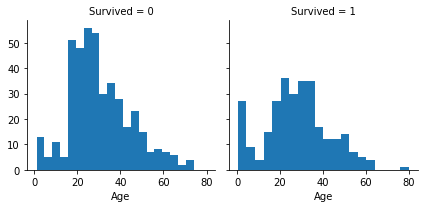

```python
g = sns.FacetGrid(train_data, col='Survived')
g.map(plt.hist, 'Age', bins=20)
plt.show()
```

Observed:

1. Infants (Age<=4) have a higher survival rate (20 bins, each bin is 4 years old).
2. All the elderly (Age=80) survived.
3. A large number of passengers aged 15-25 did not survive.
4. Passengers are mainly in the 15-35 age range.

In conclusion:

The above simple analysis verifies our previous assumptions:

1. We need to take Age into the training model.
2. Complete null value for Age feature.
3. We should divide different age groups.

### The relationship between numerical and serial features:

We can combine multiple features, and then use a simple graph to identify the relationship between them. This method can be applied to the characteristics of numerical and sub-type (Pclass), because their values are all numerical.

We can draw the histogram of Pclass through the following code:

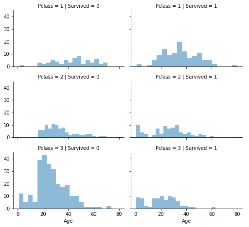

```python
grid = sns.FacetGrid(train_data, col='Survived', row='Pclass', size=2.2, aspect=1.6)
grid.map(plt.hist, 'Age', alpha=.5, bins=20)
grid.add_legend()
plt.show()
```

Observed:

In conclusion:

Consider adding Pclass features to model training.

### The relationship between discrete features and Survived:

Now we can view the relationship between discrete features and survived.

We can visualize the data in the following ways:

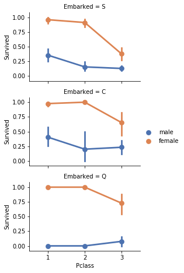

```python
grid = sns.FacetGrid(train_data, row='Embarked', size=2.2, aspect=1.6)
grid.map(sns.pointplot, 'Pclass', 'Survived', 'Sex',order=[1,2,3],hue_order=train_data.Sex.unique(),palette='deep')
grid.add_legend()
plt.show()
```

Observed:

1. Female passengers have a higher survival rate than male passengers.
2. There may not be a direct connection between Embarked and Survived.
3. For Pclass=3 and male passengers, different Embarked ports will lead to different survival rates.

In conclusion:

1. Add sex features to the training model.
2. Complete the data under the Embarked feature and add this feature to the training model.

### The relationship between discrete features and numerical features:

We may also want to find the relationship between discrete and numerical features.

We can consider looking at the relationship between Embarked (discrete non-numeric), Sex (discrete non-numeric), Fare (continuous numeric) and Survived (discrete numeric).

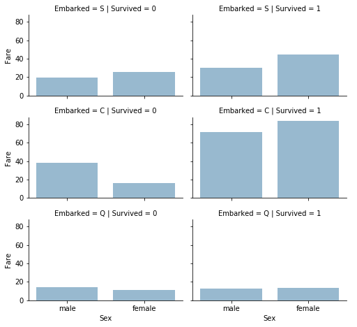

```python
grid = sns.FacetGrid(train_data, row='Embarked', col='Survived', size=2.2, aspect=1.6)
grid.map(sns.barplot, 'Sex', 'Fare', order=train_data.Sex.unique(),alpha=.5, ci=None)
grid.add_legend()
plt.show()
```

Observed:

1. Passengers who paid high fares have a higher survival rate, verifying our previous assumptions.
2. Embarked is related to survival rate, verifying the hypothesis we made before.

In conclusion:

1. Consider making Fare features into different intervals.

# 8. Processing data

We have collected some hypotheses and conclusions based on the data set and the requirements of the topic. Up to now, we have not processed any features or data.

Next, we will process the data with the goal of "correcting data", "creating data" and "completing data" based on the assumptions and conclusions we made before.

### Modify the data by discarding features:

This step is a good start. By discarding certain features, we can process fewer data points and make analysis easier.According to our previous assumptions and conclusions, We hope to discard the two features of Cabin and Ticket.

It should be noted here that in order to keep the data consistent, we need to discard both the training set and the test set at the same time.

Specific steps are as follows:

```python
print("Before", train_data.shape, test_data.shape, combine[0].shape, combine[1].shape)
```

```
Before (891, 12) (418, 11) (891, 12) (418, 11)
```

```python
train_data = train_data.drop(['Ticket', 'Cabin'], axis=1)
test_data = test_data.drop(['Ticket', 'Cabin'], axis=1)
combine = [train_data, test_data]
print('After', train_data.shape, test_data.shape, combine[0].shape, combine[1].shape)
```

```
After (891, 10) (418, 9) (891, 10) (418, 9)
```

### Create new features from existing features:

Before discarding the two features of Name and PassengerId, we hope to extract the features of Titles from the Name feature and test the relationship between Titles and survival.

```python
for dataset in combine:
        dataset['Title'] = dataset.Name.str.extract('([A-Za-z]+)\.', expand=False)

pd.crosstab(train_data['Title'], train_data['Sex'])
```

| Sex Title | female | male |
| --- | --- | --- |
| Capt | 0 | 1 |
| Col | 0 | 2 |
| Countess | 1 | 0 |
| Don | 0 | 1 |
| Dr | 1 | 6 |
| Jonkheer | 0 | 1 |
| Lady | 1 | 0 |
| Major | 0 | 2 |
| Master | 0 | 40 |
| Miss | 182 | 0 |
| Mlle | 2 | 0 |
| Mme | 1 | 0 |
| Mr | 0 | 517 |
| Mrs | 125 | 0 |
| Ms | 1 | 0 |
| Rev | 0 | 6 |
| Sir | 0 | 1 |

Before replacing some titles, we should see the average age of each titles:

```python
train_data[['Title', 'Age']].groupby(['Title'], as_index=False).mean()
```

|  | Title | Age |
| --- | --- | --- |
| 0 | Capt | 70.000000 |
| 1 | Col | 58.000000 |
| 2 | Countess | 33.000000 |
| 3 | Don | 40.000000 |
| 4 | Dr | 42.000000 |
| 5 | Jonkheer | 38.000000 |
| 6 | Lady | 48.000000 |
| 7 | Major | 48.500000 |
| 8 | Master | 4.574167 |
| 9 | Miss | 21.773973 |
| 10 | Mlle | 24.000000 |
| 11 | Mme | 24.000000 |
| 12 | Mr | 32.368090 |
| 13 | Mrs | 35.898148 |
| 14 | Ms | 28.000000 |
| 15 | Rev | 43.166667 |
| 16 | Sir | 49.000000 |

We can use higher and more common names or "Other" to replace some titles, such as:

```python
for dataset in combine:
    dataset['Title'] = dataset['Title'].replace(['Lady', 'Countess', 'Capt',
                                                 'Col', 'Don', 'Dr', 'Major',
                                                 'Rev', 'Sir', 'Jonkheer', 'Dona'], 'Other')
    dataset['Title'] = dataset['Title'].replace('Mlle', 'Miss')
    dataset['Title'] = dataset['Title'].replace('Ms', 'Miss')
    dataset['Title'] = dataset['Title'].replace('Mme', 'Mrs')

train_data[['Title', 'Survived']].groupby(['Title'], as_index=False).mean()
```

|  | Title | Survived |
| --- | --- | --- |
| 0 | Master | 0.575000 |
| 1 | Miss | 0.702703 |
| 2 | Mr | 0.156673 |
| 3 | Mrs | 0.793651 |
| 4 | Other | 0.347826 |

```python
train_data[['Title', 'Age']].groupby(['Title'], as_index=False).mean()
```

|  | Title | Age |
| --- | --- | --- |
| 0 | Master | 4.574167 |
| 1 | Miss | 21.845638 |
| 2 | Mr | 32.368090 |
| 3 | Mrs | 35.788991 |
| 4 | Other | 45.545455 |

Further, we can convert these discrete Titles into ordered numeric types:

```python
title_mapping = {"Mr":1, "Miss":2, "Mrs":3, "Master":4, "Other":5}
for dataset in combine:
    dataset['Title'] = dataset['Title'].map(title_mapping)
    dataset['Title'] = dataset['Title'].fillna(0)

train_data.head()
```

|  | PassengerId | Survived | Pclass | Name | Sex | Age | SibSp | Parch | Fare | Embarked | Title |
| --- | --- | --- | --- | --- | --- | --- | --- | --- | --- | --- | --- |
| 0 | 1 | 0 | 3 | Braund, Mr. Owen Harris | male | 22.0 | 1 | 0 | 7.2500 | S | 1 |
| 1 | 2 | 1 | 1 | Cumings, Mrs. John Bradley (Florence Briggs Th... | female | 38.0 | 1 | 0 | 71.2833 | C | 3 |
| 2 | 3 | 1 | 3 | Heikkinen, Miss. Laina | female | 26.0 | 0 | 0 | 7.9250 | S | 2 |
| 3 | 4 | 1 | 1 | Futrelle, Mrs. Jacques Heath (Lily May Peel) | female | 35.0 | 1 | 0 | 53.1000 | S | 3 |
| 4 | 5 | 0 | 3 | Allen, Mr. William Henry | male | 35.0 | 0 | 0 | 8.0500 | S | 1 |

Now we can safely discard the Name feature from the training set and test set. At the same time, we no longer need the PassengerId feature in the training set:

```python
train_data = train_data.drop(['Name', 'PassengerId'], axis=1)
test_data = test_data.drop(['Name'], axis=1)
combine = [train_data, test_data]
train_data.shape, test_data.shape
```

```
((891, 9), (418, 9))
```

```python
train_data.head()
```

|  | Survived | Pclass | Sex | Age | SibSp | Parch | Fare | Embarked | Title |
| --- | --- | --- | --- | --- | --- | --- | --- | --- | --- |
| 0 | 0 | 3 | male | 22.0 | 1 | 0 | 7.2500 | S | 1 |
| 1 | 1 | 1 | female | 38.0 | 1 | 0 | 71.2833 | C | 3 |
| 2 | 1 | 3 | female | 26.0 | 0 | 0 | 7.9250 | S | 2 |
| 3 | 1 | 1 | female | 35.0 | 1 | 0 | 53.1000 | S | 3 |
| 4 | 0 | 3 | male | 35.0 | 0 | 0 | 8.0500 | S | 1 |

```python
train_data[['Title', 'Survived']].groupby(['Title'], as_index=False).mean()
```

|  | Title | Survived |
| --- | --- | --- |
| 0 | 1 | 0.156673 |
| 1 | 2 | 0.702703 |
| 2 | 3 | 0.793651 |
| 3 | 4 | 0.575000 |
| 4 | 5 | 0.347826 |

New discovery:

In conclusion:

1. We decided to keep this new Title feature and add it to the training model.

### Convert a discrete feature

Now we can convert some features containing string data into numeric features, because in many modeling algorithms, the input parameters are required to be numeric.

This step allows us to achieve the goal of completing the data.

We can start by converting the sex feature, converting female to 1 and male to 0:

```python
for dataset in combine:
    dataset['Sex'] = dataset['Sex'].map({'female':1, 'male':0}).astype(int)

train_data.head()
```

|  | Survived | Pclass | Sex | Age | SibSp | Parch | Fare | Embarked | Title |
| --- | --- | --- | --- | --- | --- | --- | --- | --- | --- |
| 0 | 0 | 3 | 0 | 22.0 | 1 | 0 | 7.2500 | S | 1 |
| 1 | 1 | 1 | 1 | 38.0 | 1 | 0 | 71.2833 | C | 3 |
| 2 | 1 | 3 | 1 | 26.0 | 0 | 0 | 7.9250 | S | 2 |
| 3 | 1 | 1 | 1 | 35.0 | 1 | 0 | 53.1000 | S | 3 |
| 4 | 0 | 3 | 0 | 35.0 | 0 | 0 | 8.0500 | S | 1 |

### Completing continuous numerical features

Now we can start to complete the data for those features that contain null or missing values. We will first complete the data for the Age feature.

Now let's summarize three methods for completing continuous numerical feature data:

1. A simple method is to generate a random number, the range of this random number is between the mean and standard deviation of this feature
2. A more accurate approach is to use the features related to it to make a guess. In this case, we found a correlation between Age, Sex and Pclass.

So we will use the median of a series of Pclass and Sex features as the guessed Age value.

So we will have a series of guesses such as: when Pclass=1 and Sex=0, when Pclass=1 and Sex=1, etc...

1. The third method is to combine the above two methods. We can guess the missing Age value based on a series of combinations of Pclass and Sex and use the random number mentioned in the first method

Method 1 and Method 3 will introduce random noise into the model, and the results may be different multiple times. So we are more inclined to use method 2:

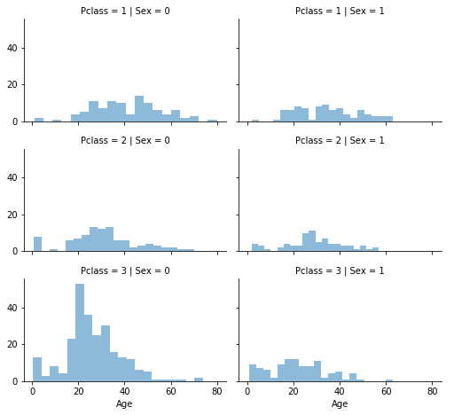

```python
grid = sns.FacetGrid(train_data, row='Pclass', col='Sex', size=2.2, aspect=1.6)
grid.map(plt.hist, 'Age', alpha=.5, bins=20)
grid.add_legend()
plt.show()
```

We first prepare an empty array to store the guessed age. Because it is a combination of Pclass and Gender, the size of the array is 2x3:

```python
guess_ages = np.zeros((2, 3))
```

Then we can iterate on Sex (0 or 1) and Pclass (1, 2, 3), and calculate the guess (Age) value obtained under the combination of 6:

```python
for dataset in combine:
    for i in range(0, 2):
        for j in range(0, 3):
            guess_data = dataset[(dataset['Sex'] == i) & (dataset['Pclass'] == j+1)]['Age'].dropna()

            age_guess = guess_data.median()

            # Convert random age float to nearest .5 age
            guess_ages[i, j] = int(age_guess / 0.5 + 0.5) * 0.5

    for i in range(0, 2):
            for j in range(0, 3):
                dataset.loc[ (dataset.Age.isnull()) & (dataset.Sex == i) & (dataset.Pclass == j+1),
                             'Age'] = guess_ages[i,j]

    dataset['Age'] = dataset['Age'].astype(int)


train_data.head()
```

|  | Survived | Pclass | Sex | Age | SibSp | Parch | Fare | Embarked | Title |
| --- | --- | --- | --- | --- | --- | --- | --- | --- | --- |
| 0 | 0 | 3 | 0 | 22 | 1 | 0 | 7.2500 | S | 1 |
| 1 | 1 | 1 | 1 | 38 | 1 | 0 | 71.2833 | C | 3 |
| 2 | 1 | 3 | 1 | 26 | 0 | 0 | 7.9250 | S | 2 |
| 3 | 1 | 1 | 1 | 35 | 1 | 0 | 53.1000 | S | 3 |
| 4 | 0 | 3 | 0 | 35 | 0 | 0 | 8.0500 | S | 1 |

Now we segment Age and check the correlation between each segment and Survived:

```python
train_data['AgeBand'] = pd.cut(train_data['Age'], 5)
train_data[['AgeBand', 'Survived']].groupby(['AgeBand'], as_index=False).mean().sort_values(by='AgeBand', ascending=True)
```

|  | AgeBand | Survived |
| --- | --- | --- |
| 0 | (-0.08, 16.0] | 0.550000 |
| 1 | (16.0, 32.0] | 0.337374 |
| 2 | (32.0, 48.0] | 0.412037 |
| 3 | (48.0, 64.0] | 0.434783 |
| 4 | (64.0, 80.0] | 0.090909 |

Then we use the ordered values to replace the values in Age according to the above segment:

```python
for dataset in combine:
    dataset.loc[ dataset['Age'] <= 16, 'Age'] = 0
    dataset.loc[(dataset['Age'] > 16) & (dataset['Age'] <= 32), 'Age'] = 1
    dataset.loc[(dataset['Age'] > 32) & (dataset['Age'] <= 48), 'Age'] = 2
    dataset.loc[(dataset['Age'] > 48) & (dataset['Age'] <= 64), 'Age'] = 3
    dataset.loc[ dataset['Age'] > 64, 'Age']

train_data.head()
```

|  | Survived | Pclass | Sex | Age | SibSp | Parch | Fare | Embarked | Title | AgeBand |
| --- | --- | --- | --- | --- | --- | --- | --- | --- | --- | --- |
| 0 | 0 | 3 | 0 | 1 | 1 | 0 | 7.2500 | S | 1 | (16.0, 32.0] |
| 1 | 1 | 1 | 1 | 2 | 1 | 0 | 71.2833 | C | 3 | (32.0, 48.0] |
| 2 | 1 | 3 | 1 | 1 | 0 | 0 | 7.9250 | S | 2 | (16.0, 32.0] |
| 3 | 1 | 1 | 1 | 2 | 1 | 0 | 53.1000 | S | 3 | (32.0, 48.0] |
| 4 | 0 | 3 | 0 | 2 | 0 | 0 | 8.0500 | S | 1 | (32.0, 48.0] |

Then we can discard the AgeBand feature:

```python
train_data = train_data.drop(['AgeBand'], axis=1)
combine = [train_data, test_data]
train_data.head()
```

|  | Survived | Pclass | Sex | Age | SibSp | Parch | Fare | Embarked | Title |
| --- | --- | --- | --- | --- | --- | --- | --- | --- | --- |
| 0 | 0 | 3 | 0 | 1 | 1 | 0 | 7.2500 | S | 1 |
| 1 | 1 | 1 | 1 | 2 | 1 | 0 | 71.2833 | C | 3 |
| 2 | 1 | 3 | 1 | 1 | 0 | 0 | 7.9250 | S | 2 |
| 3 | 1 | 1 | 1 | 2 | 1 | 0 | 53.1000 | S | 3 |
| 4 | 0 | 3 | 0 | 2 | 0 | 0 | 8.0500 | S | 1 |

### Combine existing features to create new features

Now we can create a new FamilySize feature by combining the Parch and SibSp features. This step allows us to discard the Parch and SibSp features from the data set.

```python
for dataset in combine:
    dataset['FamilySize'] = dataset['SibSp'] + dataset['Parch'] + 1

train_data[['FamilySize', 'Survived']].groupby(['FamilySize'], as_index=False).mean().sort_values(by='Survived', ascending=False)
```

|  | FamilySize | Survived |
| --- | --- | --- |
| 3 | 4 | 0.724138 |
| 2 | 3 | 0.578431 |
| 1 | 2 | 0.552795 |
| 6 | 7 | 0.333333 |
| 0 | 1 | 0.303538 |
| 4 | 5 | 0.200000 |
| 5 | 6 | 0.136364 |
| 7 | 8 | 0.000000 |
| 8 | 11 | 0.000000 |

Then we can create another feature called IsAlone:

```python
for dataset in combine:
    dataset['IsAlone'] = 0
    dataset.loc[dataset['FamilySize'] == 1, 'IsAlone'] = 1

train_data[['IsAlone', 'Survived']].groupby(['IsAlone'], as_index=False).mean()
```

|  | IsAlone | Survived |
| --- | --- | --- |
| 0 | 0 | 0.505650 |
| 1 | 1 | 0.303538 |

Based on the above data performance, we can now discard the features of Parch, SibSp, and FamilySize, and retain the features of IsAlone:

```python
train_data = train_data.drop(['Parch', 'SibSp', 'FamilySize'], axis=1)
test_data = test_data.drop(['Parch', 'SibSp', 'FamilySize'], axis=1)
combine = [train_data, test_data]
train_data.head()
```

|  | Survived | Pclass | Sex | Age | Fare | Embarked | Title | IsAlone |
| --- | --- | --- | --- | --- | --- | --- | --- | --- |
| 0 | 0 | 3 | 0 | 1 | 7.2500 | S | 1 | 0 |
| 1 | 1 | 1 | 1 | 2 | 71.2833 | C | 3 | 0 |
| 2 | 1 | 3 | 1 | 1 | 7.9250 | S | 2 | 1 |
| 3 | 1 | 1 | 1 | 2 | 53.1000 | S | 3 | 0 |
| 4 | 0 | 3 | 0 | 2 | 8.0500 | S | 1 | 1 |

```python
for dataset in combine:
    dataset['Age*Class'] = dataset.Age * dataset.Pclass

train_data.loc[:, ['Age*Class', 'Age', 'Pclass']].head(10)
```

|  | Age*Class | Age | Pclass |
| --- | --- | --- | --- |
| 0 | 3 | 1 | 3 |
| 1 | 2 | 2 | 1 |
| 2 | 3 | 1 | 3 |
| 3 | 2 | 2 | 1 |
| 4 | 6 | 2 | 3 |
| 5 | 3 | 1 | 3 |
| 6 | 3 | 3 | 1 |
| 7 | 0 | 0 | 3 |
| 8 | 3 | 1 | 3 |
| 9 | 0 | 0 | 2 |

### Complete a discrete feature

Embarked features mainly have three values, namely S, Q, C, corresponding to three embarkation ports. In the training set, this has 2 missing values, and we will use the most frequent value to fill this missing value.

```python
freq_port = train_data.Embarked.dropna().mode()[0]
freq_port
```

```
'S'
```

```python
for dataset in combine:
    dataset['Embarked'] = dataset['Embarked'].fillna(freq_port)

train_data[['Embarked', 'Survived']].groupby(['Embarked'], as_index=False).mean().sort_values(by='Survived', ascending=False)
```

|  | Embarked | Survived |
| --- | --- | --- |
| 0 | C | 0.553571 |
| 1 | Q | 0.389610 |
| 2 | S | 0.339009 |

### Convert discrete features to numeric

We can now convert discrete Embarked features to numerical features

```python
for dataset in combine:
    dataset['Embarked'] = dataset['Embarked'].map({'S': 0, 'C': 1, 'Q': 2}).astype(int)

train_data.head()
```

|  | Survived | Pclass | Sex | Age | Fare | Embarked | Title | IsAlone | Age*Class |
| --- | --- | --- | --- | --- | --- | --- | --- | --- | --- |
| 0 | 0 | 3 | 0 | 1 | 7.2500 | 0 | 1 | 0 | 3 |
| 1 | 1 | 1 | 1 | 2 | 71.2833 | 1 | 3 | 0 | 2 |
| 2 | 1 | 3 | 1 | 1 | 7.9250 | 0 | 2 | 1 | 3 |
| 3 | 1 | 1 | 1 | 2 | 53.1000 | 0 | 3 | 0 | 2 |
| 4 | 0 | 3 | 0 | 2 | 8.0500 | 0 | 1 | 1 | 6 |

### Completing numerical features

(We can also round the value of Fare to the nearest 2 digits)

```python
test_data['Fare'].fillna(test_data['Fare'].dropna().median(), inplace=True)
test_data.head()
```

|  | PassengerId | Pclass | Sex | Age | Fare | Embarked | Title | IsAlone | Age*Class |
| --- | --- | --- | --- | --- | --- | --- | --- | --- | --- |
| 0 | 892 | 3 | 0 | 2 | 7.8292 | 2 | 1 | 1 | 6 |
| 1 | 893 | 3 | 1 | 2 | 7.0000 | 0 | 3 | 0 | 6 |
| 2 | 894 | 2 | 0 | 3 | 9.6875 | 2 | 1 | 1 | 6 |
| 3 | 895 | 3 | 0 | 1 | 8.6625 | 0 | 1 | 1 | 3 |
| 4 | 896 | 3 | 1 | 1 | 12.2875 | 0 | 3 | 0 | 3 |

Next we will segment Fare:

```python
train_data['FareBand'] = pd.qcut(train_data['Fare'], 4)
train_data[['FareBand', 'Survived']].groupby(['FareBand'], as_index=False).mean().sort_values(by='FareBand', ascending=True)
```

|  | FareBand | Survived |
| --- | --- | --- |
| 0 | (-0.001, 7.91] | 0.197309 |
| 1 | (7.91, 14.454] | 0.303571 |
| 2 | (14.454, 31.0] | 0.454955 |
| 3 | (31.0, 512.329] | 0.581081 |

From the results, we can clearly see that the larger the Fare value, the higher the survival rate. In this case, we can affirm that Fare will be helpful.

According to the segmented feature FareBand, Fare is converted into an ordered numerical feature:

```python
for dataset in combine:
    dataset.loc[ dataset['Fare'] <= 7.91, 'Fare'] = 0
    dataset.loc[(dataset['Fare'] > 7.91) & (dataset['Fare'] <= 14.454), 'Fare'] = 1
    dataset.loc[(dataset['Fare'] > 14.454) & (dataset['Fare'] <= 31), 'Fare'] = 2
    dataset.loc[dataset['Fare'] > 31, 'Fare'] = 3
    dataset['Fare'] = dataset['Fare'].astype(int)

train_data = train_data.drop(['FareBand'], axis=1)
combine = [train_data, test_data]
train_data.head(10)
```

|  | Survived | Pclass | Sex | Age | Fare | Embarked | Title | IsAlone | Age*Class |
| --- | --- | --- | --- | --- | --- | --- | --- | --- | --- |
| 0 | 0 | 3 | 0 | 1 | 0 | 0 | 1 | 0 | 3 |
| 1 | 1 | 1 | 1 | 2 | 3 | 1 | 3 | 0 | 2 |
| 2 | 1 | 3 | 1 | 1 | 1 | 0 | 2 | 1 | 3 |
| 3 | 1 | 1 | 1 | 2 | 3 | 0 | 3 | 0 | 2 |
| 4 | 0 | 3 | 0 | 2 | 1 | 0 | 1 | 1 | 6 |
| 5 | 0 | 3 | 0 | 1 | 1 | 2 | 1 | 1 | 3 |
| 6 | 0 | 1 | 0 | 3 | 3 | 0 | 1 | 1 | 3 |
| 7 | 0 | 3 | 0 | 0 | 2 | 0 | 4 | 0 | 0 |
| 8 | 1 | 3 | 1 | 1 | 1 | 0 | 3 | 0 | 3 |
| 9 | 1 | 2 | 1 | 0 | 2 | 1 | 3 | 0 | 0 |

Now let's take a look at the correlation between Survived and other features

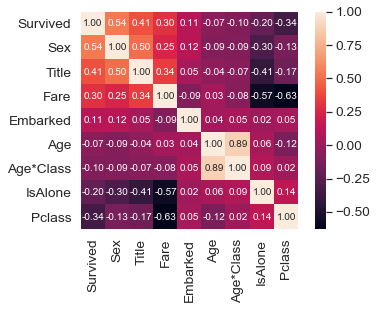

```python
corrmat = train_data.corr()

k = 10
cols = corrmat.nlargest(k,'Survived')['Survived'].index  #Take out the ten items that are most relevant to Survived
cm = np.corrcoef(train_data[cols].values.T)  #Correlation coefficient
sns.set(font_scale = 1.25)
hm = sns.heatmap(cm,cbar = True,annot = True,square = True ,fmt = '.2f',annot_kws = {'size': 10},yticklabels = cols.values,xticklabels = cols.values)
plt.show()
```

# 9. Model, predict, and solve problems

Now we are ready to train the model. After the model is trained, we can apply it to problem solving. For the prediction problem, we have at least more than 60 algorithms to choose from.

So we must understand the type of problem and the needs of the solution, so as to narrow the scope of model selection. Now this problem is a classification and regression problem,

We want to find out the relationship between the output (Survived) and other features (Gender, Age, Port, etc.). Because the training set is given, this is a supervised learning in machine learning.

So the current demand for algorithms is: supervised learning plus classification and regression. According to this condition, we have the following models to choose from:

1. Logistic Regression
2. KNN
3. SVM
4. Naive Bayes classifier
5. Decision Tree
6. Random Forrest
7. Perceptron
8. Artificial neural network
9. RVM or Relevance Vector Machine

Now we distinguish the training set from the test set:

```python
X_train = train_data.drop('Survived', axis=1)
Y_train = train_data['Survived']
X_test = test_data.drop('PassengerId', axis=1).copy()
X_train.shape, Y_train.shape, X_test.shape
```

```
((891, 8), (891,), (418, 8))
```

### Logistic Regression

Logistic Regression is a very useful model that can be used first in the workflow. It measures the relationship between discrete features and other features by using the method of estimating probability, which is an increasing logical distribution.

```python
logreg = LogisticRegression()
logreg.fit(X_train, Y_train)
Y_pred = logreg.predict(X_test)
acc_log = round(logreg.score(X_train, Y_train) * 100, 2)
acc_log
```

```
80.36
```

### SVC

Next we use SVC to analyze the data and do classification and regression analysis.

```python
svc = SVC()
svc.fit(X_train, Y_train)
Y_pred = svc.predict(X_test)
acc_svc = round(svc.score(X_train, Y_train) * 100, 2)
acc_svc
```

```
78.23
```

### KNN

In pattern recognition, the KNN algorithm is a non-parametric method used for classification and regression. If you use KNN to analyze this problem:

```python
knn = KNeighborsClassifier(n_neighbors = 3)
knn.fit(X_train, Y_train)
Y_pred = knn.predict(X_test)
acc_knn = round(knn.score(X_train, Y_train) * 100, 2)
acc_knn
```

```
84.74
```

It can be seen that the correct rate of using KNN is higher than that of SVM

### Naive Bayes

Let's try Naive Bayes:

```python
gaussian = GaussianNB()
gaussian.fit(X_train, Y_train)
Y_pred = gaussian.predict(X_test)
acc_gaussian = round(gaussian.score(X_train, Y_train) * 100, 2)
acc_gaussian
```

```
72.28
```

It seems that using Naive Bayes in this problem is not a good choice. From the current point of view, its correct rate is the lowest.

### Perceptron

Next we try the perceptron algorithm, which can be used for two classification problems:

```python
perceptron = Perceptron()
perceptron.fit(X_train, Y_train)
Y_pred = perceptron.predict(X_test)
acc_perceptron = round(perceptron.score(X_train, Y_train) * 100, 2)
acc_perceptron
```

```
78.34
```

It can be seen that the correct rate of perceptron is not high.

### Linear SVC

Next try Linear SVC:

```python
linear_svc = LinearSVC()
linear_svc.fit(X_train, Y_train)
Y_pred = linear_svc.predict(X_test)
acc_linear_svc = round(linear_svc.score(X_train, Y_train) * 100, 2)
acc_linear_svc
```

```
79.12
```

### SGD

```python
sgd = SGDClassifier()
sgd.fit(X_train, Y_train)
Y_pred = sgd.predict(X_test)
acc_sgd = round(sgd.score(X_train, Y_train) * 100, 2)
acc_sgd
```

```
68.69
```

### Decision tree algorithm

Next we look at the very common model: Decision tree algorithm:

```python
decision_tree = DecisionTreeClassifier()
decision_tree.fit(X_train, Y_train)
Y_pred = decision_tree.predict(X_test)
acc_decision_tree = round(decision_tree.score(X_train, Y_train) * 100, 2)
acc_decision_tree
```

```
86.76
```

It can be seen that the algorithm using the decision tree makes the accuracy rate reach a higher value. So far, its correct rate is the highest.

### Random forest

Then we look at the random forest, which is accomplished by combining multiple decision tree algorithms:

```python
random_forest = RandomForestClassifier(n_estimators=100)
random_forest.fit(X_train, Y_train)
Y_pred = random_forest.predict(X_test)
acc_random_forest = round(random_forest.score(X_train, Y_train) * 100, 2)
acc_random_forest
```

```
86.76
```

# 10 Model evaluation

```python
models = pd.DataFrame({
    'Model': ['Support Vector Machines', 'KNN', 'Logistic Regression',
              'Random Forest', 'Naive Bayes', 'Perceptron',
              'Stochastic Gradient Decent', 'Linear SVC',
              'Decision Tree'],
    'Score': [acc_svc, acc_knn, acc_log,
              acc_random_forest, acc_gaussian, acc_perceptron,
              acc_sgd, acc_linear_svc, acc_decision_tree]})

models.sort_values(by='Score', ascending=False)
```

|  | Model | Score |
| --- | --- | --- |
| 3 | Random Forest | 86.76 |
| 8 | Decision Tree | 86.76 |
| 1 | KNN | 84.74 |
| 2 | Logistic Regression | 80.36 |
| 7 | Linear SVC | 79.12 |
| 5 | Perceptron | 78.34 |
| 0 | Support Vector Machines | 78.23 |
| 4 | Naive Bayes | 72.28 |
| 6 | Stochastic Gradient Decent | 68.69 |

We can use Logistic Regression to verify the assumptions and conclusions we have made. This can be achieved by calculating the coefficient of the characteristic value. Positive coefficients can increase the log odds (thus increasing the probability), and negative coefficients will reduce the log odds (thus reducing the probability):

```python
coeff_data = pd.DataFrame(train_data.columns.delete(0))
coeff_data.columns = ['Feature']
coeff_data["Correlation"] = pd.Series(logreg.coef_[0])
coeff_data.sort_values(by='Correlation', ascending=False)
```

|  | Feature | Correlation |
| --- | --- | --- |
| 1 | Sex | 2.201619 |
| 5 | Title | 0.397888 |
| 2 | Age | 0.287011 |
| 4 | Embarked | 0.261473 |
| 6 | IsAlone | 0.126553 |
| 3 | Fare | -0.086655 |
| 7 | Age*Class | -0.311069 |
| 0 | Pclass | -0.750700 |

From the above results, we can see:

1. Sex is the characteristic with the highest positive coefficient. This surface is that when the value of Sex increases (from male:0 to female:1), the probability of Survived=1 increases the most.
2. Conversely, when Pclass increases, the probability of Survived=1 decreases the most.
3. From the results, the new feature Age*Class we created is very useful because it has the second highest negative correlation with Survived.
4. Title is the second highest positive coefficient feature.

Among them, decision tree and random forest have the highest correct rate, but we will choose the random forest algorithm here. Because Random forests are an ensemble learning method for classification (and regression) that operate by constructing a multitude of decision trees at training time and outputting the class that is the mode of the classes output by individual trees. The last but not the least, it makes up for the problem of decision tree overfitting.

As seen from previous data analysis and feature engineering results, Titanic passengers' survival law is in full compliance with the "gentleman concept" that has been recognized by the society-ladies and children first. The survival rate of women and children is much higher than that of others. But what we can make predictions, and since it is a prediction, there must be unpredictable circumstances. Therefore, I think the most important thing is not the predicted result (of course, the higher the accuracy rate, the better), but the laws and phenomena discovered after data analysis and processing in the entire project, and practical application of these experiences in subsequent projects to avoid a similar mistake. In China, there is a saying "The failure of the past is the lesson of the future." Simultaneously, the most difficult and most important thing in the entire project is not selecting models, but the acquisition of data, optimization work and feature engineering—the better the data, the better the model. By the way, I think I won't embark on the Titanic because as a 25-year-old man, I will devote my alive chance to other ladies or children.